# TD1

2023-02-03

1. Importer le jeu de données dans R

Le bloc de code suivant permet de charger dans R un fichier au format Excel.

```r
library(readxl)
fifa22 <- read_excel("fifa22.xlsx")
```

Nous venons d’importer la base de données dans R en lui donnant le nom fifa22. C’est avec ce nom que nous nous référons à la base de données plus tard dans le reste du code.

2. Afficher les noms des colonnes du jeu de données actif

On utilise la fonction colnames(fifa22) pour afficher les noms des colonnes qui sont dans la base de données. Cela nous permet de vérifier que la base de donnée a été importée correctement.

```r
colnames(fifa22)
```

```
##  [1] "short_name"                  "player_positions"
##  [3] "overall"                     "potential"
##  [5] "value_eur"                   "wage_eur"
##  [7] "age"                         "dob"
##  [9] "height_cm"                   "weight_kg"
## [11] "club_team_id"                "club_name"
## [13] "league_name"                 "league_level"
## [15] "club_position"               "club_jersey_number"
## [17] "club_loaned_from"            "club_joined"
## [19] "club_contract_valid_until"   "nationality_id"
## [21] "nationality_name"            "nation_team_id"
## [23] "nation_position"             "nation_jersey_number"
## [25] "preferred_foot"              "weak_foot"
## [27] "skill_moves"                 "international_reputation"
## [29] "work_rate"                   "body_type"
```

[output cut: 22 more lines]

3. Afficher les types de données de chaque colonne

Nous allons utiliser la fonction str(fifa22) pour afficher la structure de la base de donnée.

Cette fonction affiche aussi les types de données pour chaque type de colonne. Par exemple chr pour des données texte, num pour des données numériques. Il y a des opérations qui ne sont permises que pour certains types de données.

```r
str(fifa22)
```

```
## tibble [19,239 × 74] (S3: tbl_df/tbl/data.frame)
##  $ short_name                 : chr [1:19239] "L, Messi" "R, Lewandowski" "Cristiano Ronaldo" "Neymar Jr" ...
##  $ player_positions           : chr [1:19239] "RW, ST, CF" "ST" "ST, LW" "LW, CAM" ...
##  $ overall                    : num [1:19239] 93 92 91 91 91 91 91 90 90 90 ...
##  $ potential                  : num [1:19239] 93 92 91 91 91 93 95 90 92 90 ...
##  $ value_eur                  : num [1:19239] 7.80e+07 1.20e+08 4.50e+07 1.29e+08 1.26e+08 ...
##  $ wage_eur                   : num [1:19239] 320000 270000 270000 270000 350000 130000 230000 86000 250000 240000 ...
##  $ age                        : num [1:19239] 34 32 36 29 30 28 22 35 29 27 ...
##  $ dob                        : POSIXct[1:19239], format: "1987-06-24" "1988-08-21" ...
##  $ height_cm                  : num [1:19239] 170 185 187 175 181 188 182 193 187 188 ...
##  $ weight_kg                  : num [1:19239] 72 81 83 68 70 87 73 93 85 89 ...
##  $ club_team_id               : num [1:19239] 73 21 11 73 10 240 73 21 241 18 ...
##  $ club_name                  : chr [1:19239] "Paris Saint-Germain" "FC Bayern München" "Manchester United" "Paris Saint-Germain" ...
##  $ league_name                : chr [1:19239] "French Ligue 1" "German 1, Bundesliga" "English Premier League" "French Ligue 1" ...
##  $ league_level               : num [1:19239] 1 1 1 1 1 1 1 1 1 1 ...
```

[output cut: 60 more lines]

4. Est-ce que R a correctement reconnu le type de chaque colonne ?

Pour la plupart des données, R semble avoir bien reconnu le type des données. Par contre toutes les données qui comportent du texte ont été lus comme chr alors que certaines données texte peuvent représenter des catégories. Par exemple la variable work_rate représente une catégorie (plusieurs joueurs peuvent être caractérisés pour un même work_rate, cette donnée n’est pas unique à chaque joueur).

```r
aggregate(wage_eur ~ league_name, data = fifa22, FUN = mean)
```

```
##                             league_name   wage_eur
## 1            Argentina Primera División  6140.9904
## 2           Australian Hyundai A-League  1638.4477
## 3          Austrian Football Bundesliga  5206.2121
## 4            Belgian Jupiler Pro League  7422.7459
## 5         Campeonato Brasileiro Série A 15263.8889
## 6           Chilian Campeonato Nacional  2016.4516
## 7                  Chinese Super League  4255.8296
## 8               Colombian Liga Postobón   951.0471
## 9                     Croatian Prva HNL   591.0714
## 10               Cypriot First Division   601.7857
## 11        Czech Republic Gambrinus Liga   739.2405
## 12                     Danish Superliga  4234.2767
## 13                   Ecuadorian Serie A   550.0000
## 14          English League Championship 11440.9344
```

[output cut: 41 more lines]

```r
wage_league <- aggregate(wage_eur ~ league_name, data = fifa22, FUN = mean)
arrange(wage_league, -wage_eur)
```

```
##                             league_name   wage_eur
## 1                English Premier League 50847.6994
## 2                Spain Primera Division 31128.8310
## 3                       Italian Serie A 31004.5293
## 4                  German 1, Bundesliga 24407.7132
## 5                Russian Premier League 24213.4146
## 6                        French Ligue 1 21462.7383
## 7         Campeonato Brasileiro Série A 15263.8889
## 8                       Mexican Liga MX 12220.0820
## 9                     Turkish Süper Lig 11915.1013
## 10          English League Championship 11440.9344
## 11         Saudi Abdul L, Jameel League  8381.0897
## 12           Belgian Jupiler Pro League  7422.7459
## 13                 Scottish Premiership  6782.5000
## 14           Portuguese Liga ZON SAGRES  6335.8416
```

[output cut: 41 more lines]

7. Afficher le potentiel moyen des joueurs par ligue

```r
potential_league <- aggregate(potential ~ league_name, data = fifa22, FUN = mean)
arrange(potential_league, -potential)
```

```
##                             league_name potential
## 1                English Premier League  78.99693
## 2                Spain Primera Division  78.69510
## 3              Ukrainian Premier League  77.57143
## 4                       Italian Serie A  77.19361
## 5                  German 1, Bundesliga  77.14519
## 6                        French Ligue 1  76.69671
## 7                Russian Premier League  76.34146
## 8         Czech Republic Gambrinus Liga  75.27848
## 9                    Greek Super League  75.00893
## 10                    Croatian Prva HNL  74.64286
## 11           Portuguese Liga ZON SAGRES  74.56634
## 12                   Holland Eredivisie  73.59959
## 13           Belgian Jupiler Pro League  73.25410
## 14             Spanish Segunda División  72.79040
```

[output cut: 41 more lines]

8. Afficher le salaire moyen des joueurs par niveau de réputation

```r
aggregate(wage_eur ~ international_reputation, data = fifa22, FUN = mean)
```

```
##   international_reputation   wage_eur
## 1                        1   5948.719
## 2                        2  34924.396
## 3                        3  73034.629
## 4                        4 153368.421
## 5                        5 191500.000
```

9. Le salaire moyen des joueurs par ligue et par réputation internationale

```r
aggregate(wage_eur ~ league_name +international_reputation, data = fifa22, FUN = mean)
```

```
##                              league_name international_reputation    wage_eur
## 1             Argentina Primera División                        1   5883.0703
## 2            Australian Hyundai A-League                        1   1637.1377
## 3           Austrian Football Bundesliga                        1   5119.4190
## 4             Belgian Jupiler Pro League                        1   7104.4492
## 5          Campeonato Brasileiro Série A                        1  15263.8889
## 6            Chilian Campeonato Nacional                        1   2016.4516
## 7                   Chinese Super League                        1   3761.8056
## 8                Colombian Liga Postobón                        1    951.0471
## 9                      Croatian Prva HNL                        1    573.5849
## 10                Cypriot First Division                        1    600.0000
## 11         Czech Republic Gambrinus Liga                        1    732.4675
## 12                      Danish Superliga                        1   4235.0158
## 13                    Ecuadorian Serie A                        1    550.0000
## 14           English League Championship                        1  11311.3861
```

[output cut: 116 more lines]

10. Afficher les statistiques générales de toutes les données numériques

```r
# Récupérer les colonnes qui ne contiennent que des données numériques
num_cols <- select(fifa22, where(is.numeric))
summary(num_cols)
```

```
##     overall        potential       value_eur           wage_eur
##  Min.   :47.00   Min.   :49.00   Min.   :9.00e+03   Min.   :   500
##  1st Qu.:61.00   1st Qu.:67.00   1st Qu.:4.75e+05   1st Qu.:  1000
##  Median :66.00   Median :71.00   Median :9.75e+05   Median :  3000
##  Mean   :65.77   Mean   :71.08   Mean   :2.85e+06   Mean   :  9018
##  3rd Qu.:70.00   3rd Qu.:75.00   3rd Qu.:2.00e+06   3rd Qu.:  8000
##  Max.   :93.00   Max.   :95.00   Max.   :1.94e+08   Max.   :350000
##                                  NA's   :74         NA's   :61
##       age          height_cm       weight_kg       club_team_id
##  Min.   :16.00   Min.   :155.0   Min.   : 49.00   Min.   :     1
##  1st Qu.:21.00   1st Qu.:176.0   1st Qu.: 70.00   1st Qu.:   479
##  Median :25.00   Median :181.0   Median : 75.00   Median :  1938
##  Mean   :25.21   Mean   :181.3   Mean   : 74.94   Mean   : 50581
##  3rd Qu.:29.00   3rd Qu.:186.0   3rd Qu.: 80.00   3rd Qu.:111139
##  Max.   :54.00   Max.   :206.0   Max.   :110.00   Max.   :115820
##                                                   NA's   :61
##   league_level   club_jersey_number club_contract_valid_until nationality_id
##  Min.   :1.000   Min.   : 1.00      Min.   :2021              Min.   :  1.0
##  1st Qu.:1.000   1st Qu.: 9.00      1st Qu.:2022              1st Qu.: 21.0
##  Median :1.000   Median :18.00      Median :2022              Median : 45.0
##  Mean   :1.354   Mean   :20.95      Mean   :2023              Mean   : 58.6
##  3rd Qu.:1.000   3rd Qu.:27.00      3rd Qu.:2024              3rd Qu.: 60.0
##  Max.   :5.000   Max.   :99.00      Max.   :2031              Max.   :219.0
##  NA's   :61      NA's   :61         NA's   :61
##  nation_team_id   nation_jersey_number   weak_foot      skill_moves
##  Min.   :  1318   Min.   : 1.00        Min.   :1.000   Min.   :1.000
##  1st Qu.:  1338   1st Qu.: 7.00        1st Qu.:3.000   1st Qu.:2.000
##  Median :  1357   Median :12.00        Median :3.000   Median :2.000
##  Mean   : 14481   Mean   :12.57        Mean   :2.946   Mean   :2.352
##  3rd Qu.:  1386   3rd Qu.:19.00        3rd Qu.:3.000   3rd Qu.:3.000
##  Max.   :111473   Max.   :28.00        Max.   :5.000   Max.   :5.000
##  NA's   :18480    NA's   :18480
##  international_reputation release_clause_eur       pace          shooting
##  Min.   :1.000            Min.   :    16000   Min.   :28.00   Min.   :18.00
##  1st Qu.:1.000            1st Qu.:   806000   1st Qu.:62.00   1st Qu.:42.00
##  Median :1.000            Median :  1600000   Median :69.00   Median :54.00
##  Mean   :1.094            Mean   :  5374044   Mean   :68.21   Mean   :52.35
##  3rd Qu.:1.000            3rd Qu.:  3700000   3rd Qu.:76.00   3rd Qu.:63.00
##  Max.   :5.000            Max.   :373500000   Max.   :97.00   Max.   :94.00
##                           NA's   :1176        NA's   :2132    NA's   :2132
```

[output cut: 73 more lines]

```
##  Min.   : 2.00      Min.   : 2.00        Min.   : 2.00
##  1st Qu.: 8.00      1st Qu.: 8.00        1st Qu.: 8.00
##  Median :11.00      Median :11.00        Median :11.00
##  Mean   :16.41      Mean   :16.19        Mean   :16.06
##  3rd Qu.:14.00      3rd Qu.:14.00        3rd Qu.:14.00
##  Max.   :91.00      Max.   :92.00        Max.   :93.00
##
##  goalkeeping_positioning goalkeeping_reflexes goalkeeping_speed
##  Min.   : 2.00           Min.   : 2.00        Min.   :15.00
##  1st Qu.: 8.00           1st Qu.: 8.00        1st Qu.:27.00
##  Median :11.00           Median :11.00        Median :36.00
##  Mean   :16.23           Mean   :16.49        Mean   :36.44
##  3rd Qu.:14.00           3rd Qu.:14.00        3rd Qu.:45.00
##  Max.   :92.00           Max.   :90.00        Max.   :65.00
##                                               NA's   :17107
```

```r
matrice_cor <- cor(fifa22[, c("height_cm", "weight_kg", "skill_dribbling", "skill_ball_control",
"movement_acceleration", "movement_agility", "power_shot_power",
"power_jumping", "power_stamina", "power_strength", "mentality_aggression",
"mentality_interceptions", "defending_marking_awareness",
"defending_standing_tackle", "defending_sliding_tackle", "goalkeeping_diving",
"goalkeeping_handling", "goalkeeping_kicking", "goalkeeping_speed"
)])
matrice_cor
```

```
##                               height_cm   weight_kg skill_dribbling
## height_cm                    1.00000000  0.76546497     -0.47722695
## weight_kg                    0.76546497  1.00000000     -0.39736339
## skill_dribbling             -0.47722695 -0.39736339      1.00000000
## skill_ball_control          -0.40044020 -0.32380447      0.94350556
## movement_acceleration       -0.54500306 -0.48406909      0.75265867
## movement_agility            -0.62125782 -0.53468931      0.77499611
## power_shot_power            -0.15834149 -0.04979448      0.61496607
## power_jumping                0.01376905  0.07779220      0.14762066
## power_stamina               -0.28573475 -0.21964064      0.70618677
## power_strength               0.53196978  0.61222054      0.02053652
## mentality_aggression        -0.06241041  0.00607201      0.50062088
## mentality_interceptions     -0.07881204 -0.05616780      0.34531940
## defending_marking_awareness -0.08849788 -0.06412353      0.37602477
## defending_standing_tackle   -0.09529724 -0.08221217      0.35713267
## defending_sliding_tackle    -0.09527953 -0.08471887      0.32717174
## goalkeeping_diving           0.37110536  0.34333436     -0.77469826
## goalkeeping_handling         0.36848239  0.34125011     -0.77298454
## goalkeeping_kicking          0.36694826  0.34157036     -0.77045400
## goalkeeping_speed                    NA          NA              NA
##                             skill_ball_control movement_acceleration
## height_cm                           -0.4004402            -0.5450031
## weight_kg                           -0.3238045            -0.4840691
## skill_dribbling                      0.9435056             0.7526587
## skill_ball_control                   1.0000000             0.6894414
## movement_acceleration                0.6894414             1.0000000
## movement_agility                     0.7134145             0.8263079
## power_shot_power                     0.6107833             0.3496392
## power_jumping                        0.2140674             0.1823060
## power_stamina                        0.7476164             0.6088963
## power_strength                       0.1345147            -0.1364551
## mentality_aggression                 0.5989598             0.2923293
## mentality_interceptions              0.4588383             0.1966129
## defending_marking_awareness          0.4900699             0.2259176
## defending_standing_tackle            0.4651916             0.2140072
## defending_sliding_tackle             0.4306140             0.2022817
## goalkeeping_diving                  -0.8040372            -0.6303076
## goalkeeping_handling                -0.8025676            -0.6302370
## goalkeeping_kicking                 -0.7990878            -0.6284665
## goalkeeping_speed                           NA                    NA
```

[output cut: 105 more lines]

```
## movement_acceleration                -0.6284665                NA
## movement_agility                     -0.5546082                NA
## power_shot_power                     -0.2669442                NA
## power_jumping                        -0.2098468                NA
## power_stamina                        -0.7033818                NA
## power_strength                       -0.1199343                NA
## mentality_aggression                 -0.5956900                NA
## mentality_interceptions              -0.5090585                NA
## defending_marking_awareness          -0.5528777                NA
## defending_standing_tackle            -0.5519312                NA
## defending_sliding_tackle             -0.5313626                NA
## goalkeeping_diving                    0.9684144                NA
## goalkeeping_handling                  0.9680493                NA
## goalkeeping_kicking                   1.0000000                NA
## goalkeeping_speed                            NA                 1
```

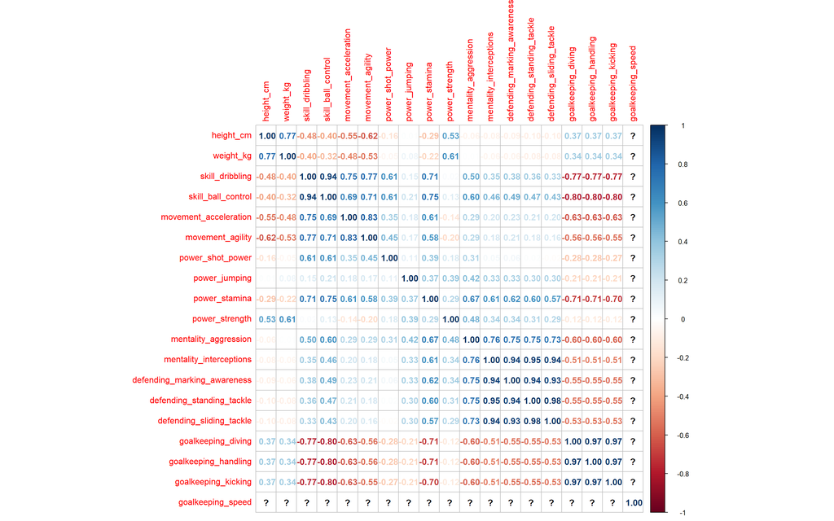

```r
corrplot(matrice_cor, method = "number")
```